# Simulating sequences for feature filtering

30/09/2020

## Wstęp

**1. Cel**

Reprezentacja przestrzeni sekwencji za pomocą k-merów

**2. Trudność**

Dla 20-elementowego alfabetu otrzymujemy:

```r
# A 6000x12209151 simple triplet matrix.
```

**3. Rozwiązanie**

Filtrowanie k-merów

## Dane

Podział ze względu na alfabet:

- alfabety długości: \(\{4, 6, 20\}\)
- różne prawdopodobieństwa występowania danych elementów

Podział ze względu na charakterystykę zbioru danych:

- zbiory o liczbie obserwacji: \(n=6000\) (\(50\%\) pozytywnych)
- długości sekwencji: \(\{10, 20, 40, 80\}\)
- liczba motywów umieszczonych w sekwencji: \(\{1, 2, 3\}\)
- liczba replikacji: \(100\)

## Jak zaprojektować konkretne zbiory danych?

## Dane eksperymentalne

**Cel**

Korelacja danych symulowanych ze zbiorami rzeczywistymi

**Plan**

- zbadanie danych symulacyjnych w pierwotnej postaci
- subsampling zbiorów by zmienić balans klas  
  (\(\{0.1, 0.25, 0.75, 0.9\}\))
- subsampling zbiorów tak, by różne motywy powodowały `pozytywność` obserwacji

## Filtry

- Metody zwracające zestaw istotnych cech
- Metody zwracające ranking cech
- Połączenia powyższych (np. testy statystyczne)

## Filtry cd.

- QuiPT
- test \(\chi^2\)
- FCBF (Fast Correlation Based Filter)
- metody oparte o informację wzajemną  
  (pakiet `praznik`, np. MRMR)
- IG, Gain Ratio, Symmetrical Uncertainty

## Czy to odpowiedni zestaw filtrów?

## Jak badać skuteczność filtrów?

## Podejście bezmodelowe

### Mierzymy miary takie jak:

- czułość
- specyficzonść
- F1-score

### k-mer uznajemy za pozytywny, gdy:

- jest równy motywowi
- zawiera motyw i jest nie dłuższy, niż \(\left \lfloor{(len(seq)+1)/4}\right \rfloor +1\)
- jest częścią motywu

## Czy pozytywność k-meru (wg naszej definicji) oznacza istotność zmiennej?

## Jak wykorzystać metody rankingowe w podejściu bezmodelowym?

## Podejście modelowe

Na podstawie utworzonego rankingu zmiennych budujemy model dla kolejnych podzbiorów cech

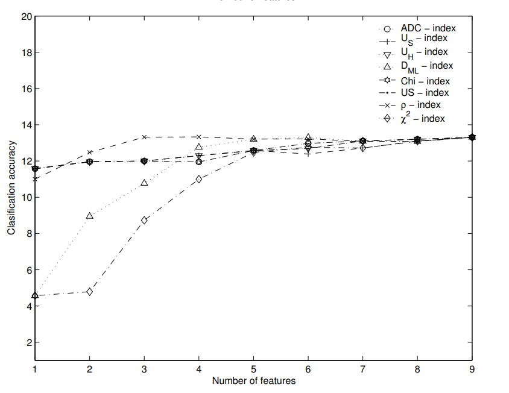

## Jakie modele wykorzystać?

## Podejście modelowe - modele

Z uwagi na postać modelu:

- Regresja Logistyczna
- k-NN

Czy warto wykorzystać inne metody?

## Jak powinien wyglądać schemat ewaluacji?

## Schemat ewaluacji

Jakimi metrykami mierzyć skuteczność modelu?

- accuracy
- sensitivity, specificity, F1-score
- AUC

## Schemat ewaluacji cd.

Jak wyglądać powinien schemat walidacyjny?

- Train/test
- Cross validation

## Jakie podzbiory cech badać?

- Ustalona frakcja k-merów

```r
# Dla frakcji(60k cech)
60000 * 0.01
```

```
## [1] 600
```

```r
# dla 12kk cech
12000000 * 0.01
```

```
## [1] 120000
```

- Ustalona liczba k-merów

```r
# Dla ustalonej liczby(60k cech)
600 / 60000
```

```
## [1] 0.01
```

```r
# dla 12kk cech
600 / 12000000
```

```
## [1] 5e-05
```

## Dziękuję za uwagę :)